# Modeling latent changes in COVID-19 transmission over time

Andrew Tredennick

06 May, 2020

## Overview

The current *Georgia stochostic model* of COVID-19 tranmission incorporates a metric of human movement ($\phi(t)$) that moderates the baseline tranmission rate ($\beta$): $\beta(t) = \phi(t)\beta$. This formulation is meant to represent the impact of social distancing. Social distancing, while powerful, is not the only practice that can reduce transmission. Other practices, such as wearing face coverings, maintaining social distance in public spaces, and enhanced cleaning practices, can also reduce transmission. These practices are difficult to quantify in data and, in turn, are difficult to model explicitly. Nonetheless, we expect that mobility data will become less informative of transmission over time and that other practices will play a larger role.

I used a basis function approach (spline modeling) to model a latent temporal process that mediates baseline tranmission rate. The idea is to include a smooth temporal function in the model that stands in for all unobserved processes that can reduce transmission.

## Implementation

We currently model the force of infection ($f$) at time $t$ as:

$$f(t) = \phi(t)\frac{\beta}{N} (I(t)),$$

where, for simplicity, $I$ stands for all infectious individuals at time $t$. The mobility index $\phi$ looks like this:

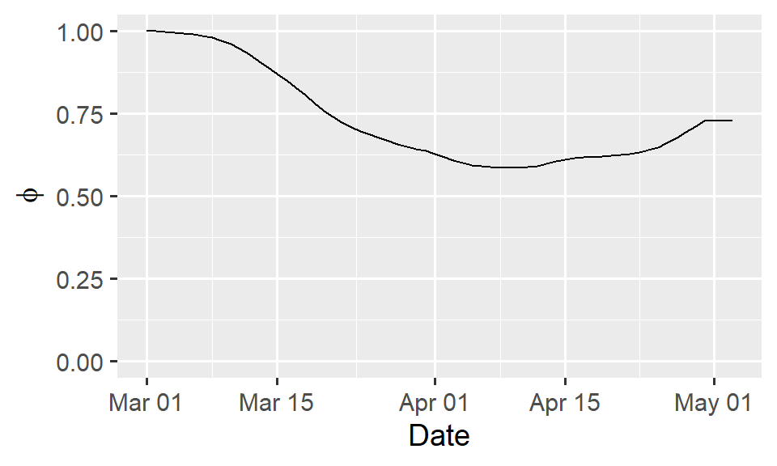

I proposed to add a temporal basis function to incorporate additional tranmission reduction over time that we cannot observe. Let the new temporal term be $\psi$, which is modeled as:

$$\text{logit}\left(\psi(t)\right) = \sum_{i=1}^K q_i \xi_{i_t},$$

where $K$ is the number of knots, $\mathbf{q}$ is a vector of spline coefficients (to be fitted), and $\mathbf{\xi}$ is a matrix basis functions. I define the number of knots ($K$) as the number of days in the data set divided by 7 (so, one knot per week). Note the logit transformation to go from the linear scale to the 0 - 1 scale. Thus, $f(t)$ becomes: $f(t) = \psi(t)\phi(t)\frac{\beta}{N} (I(t))$.

Assuming $K = 9$, the basis functions are:

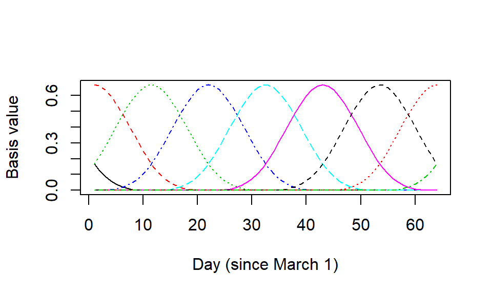

Assuming a vector of $\mathbf{q}$ values drawn from a normal distribution with mean 0 and unit variance, the resulting function can look like this:

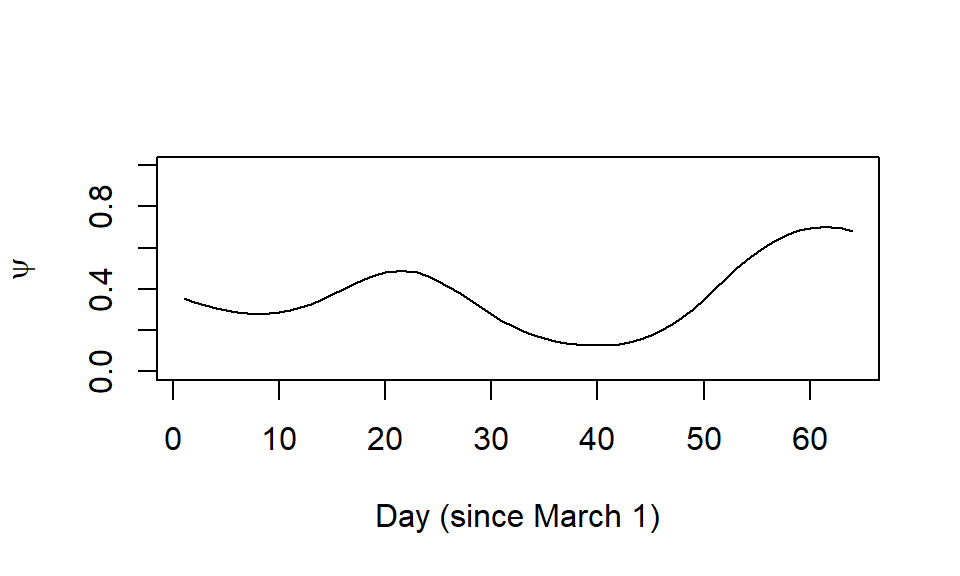

Using MIF, we actually fit the $\mathbf{q}$ values to find the best $\psi$ trend.

## Results

I fit two models to data through May 3, 2020, one model with the new basis function and one without. Here are the data:

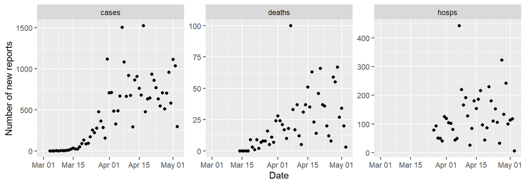

The fitted spline coefficients produce a trend over time, which I plot with the mobility trend and their combined influence on tranmission. Recall that “phi” is the mobility metric and “psi” is the latent metric produced by the spline fit.

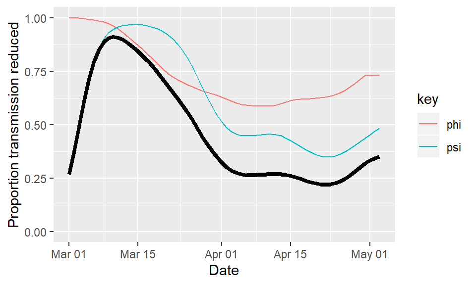

And here are the two model fits. Note that both models include the mobility covariate; the “spline” model also includes the spline fit which additionaly augments the transmission rate (thick line in the figure above).

### With spline

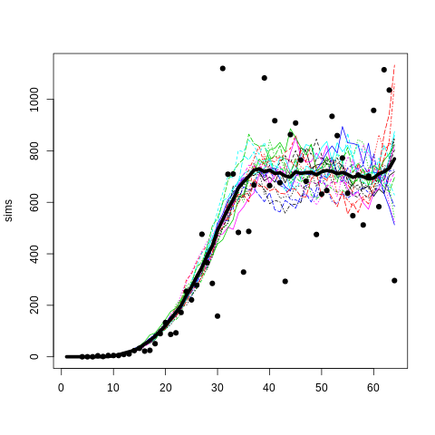

Fit of model to data with the spline for tranmission reduction (cases). Heavy black line is the mean across all MLEs within 2 likelihood points of the maximum. Colored lines show individual MLE trajectories.

### Without spline

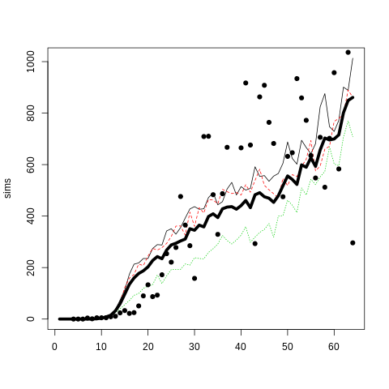

Fit of model to data with no spline for tranmission reduction (cases). Heavy black line is the mean across all MLEs within 2 likelihood points of the maximum. Colored lines show individual MLE trajectories.

### Model comparison

Here I compare the models via log likelihood and AIC. Note that for AIC I just assume that the no spline model has 0 parameters and that the spline model has 9 parameters. This gets at the relative difference between the two: the nine basis function coefficients.

| Model | Log Likelihood | AIC |
| --- | --- | --- |
| Without Spline | -800.8172 | 1601.634 |
| WIth Spline | -792.1416 | 1602.283 |

### Parameter estimates

#### MLEs from no spline fit

| MLE | Names |
| --- | --- |
| 0.4130048 | beta_s |
| 0.5264463 | max_detect_frac |
| 0.2556671 | frac_hosp |
| 0.4611072 | frac_dead |
| 2.4377413 | theta_cases |
| 2.7026601 | theta_hosps |
| 1.6690228 | theta_deaths |
| 0.0168301 | sigma_dw |

#### MLEs from spline fit

| MLE | Names |
| --- | --- |
| 0.7273171 | beta_s |
| 0.0893249 | max_detect_frac |
| 0.2405977 | frac_hosp |
| 0.7739772 | frac_dead |
| 6.4921761 | theta_cases |
| 2.2715550 | theta_hosps |
| 1.0232556 | theta_deaths |
| 0.0134870 | sigma_dw |

## Discussion

Both models are equivalent according to AIC; judging be log likelihood alone, the “with spline” model is superior. The two models lead to rather different trajectories. The “with spline” model suggests a flattening of the curve. The “no spline” model (which is the default) suggests a continual growth in number of cases.

I think the real question is whether we “buy” the resulting trend suggested by the fitted model in terms of how $\beta$ is modulated by mobility data and the latent process. In particular, including the spline affects the estimates of fraction detected, fraction hospitalized, and fraction that die once in hospital. The estimates for these parameters seem much more plausible in the model *without the spline*.

## Questions moving forward

1. Do we stop this line of work given the unrealistic parameter estimates?
2. Do implement the underlying spline trend in some other way?